# Problem Set 2

Margot Berman

2024-03-03

# Question 1

**Determine if the variable is stationary. Provide any and all evidence you have to support your answer (e.g. plots, ADF test statistic, etc.).**

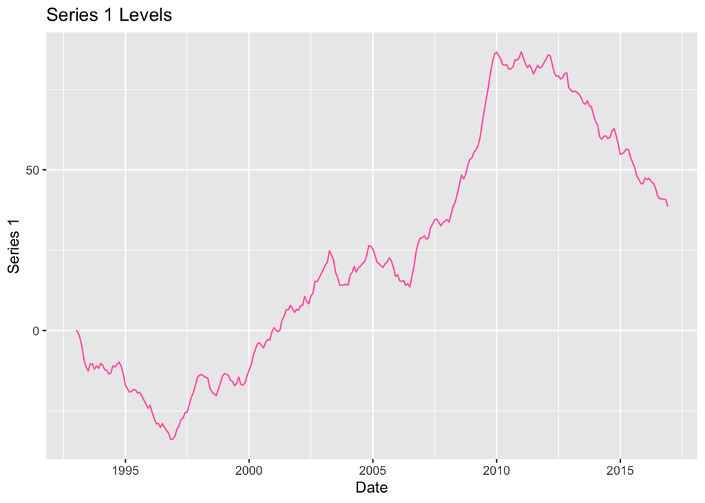

```r
#plotting series 1
ggplot(data=data) +
  geom_line(aes(x=date, y=series_one), colour="hotpink") +
  ggtitle("Series 1 Levels") +
  labs(y = "Series 1", x = "Date")
```

Series 1 is not stationary. First, the graph appears to have somewhat of a trend. However, that trend is only in the middle section of the data and the oldest and most recent years appear to be moving toward what might be classified as the mean of the series. Potentially, if we had more years of data, we might see that the series is actually stationary. However, with the amount of data we have here, we see no evidence to suggest it is.

Further, using the Augmented Dickey-Fuller Test, we fail to reject the null that the data is non-stationary at every level from 1% to 10%.

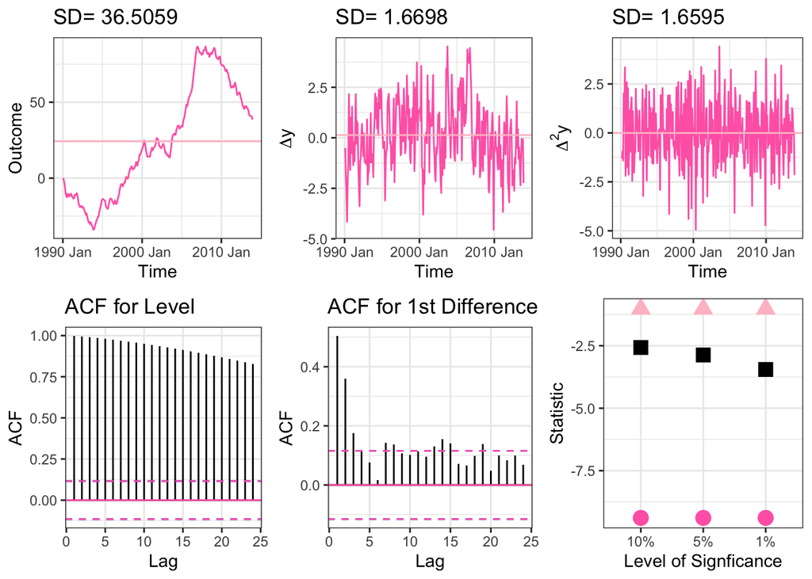

```
## $test_results
##   level crit_value ADF_round1_stat ADF_round2_stat round_1_dec round_2_dec
## 1   10%      -2.57           -1.02           -9.39         FTR         REJ
## 2    5%      -2.87           -1.02           -9.39         FTR         REJ
## 3    1%      -3.45           -1.02           -9.39         FTR         REJ
```

```r
intord(data$series_one)
```

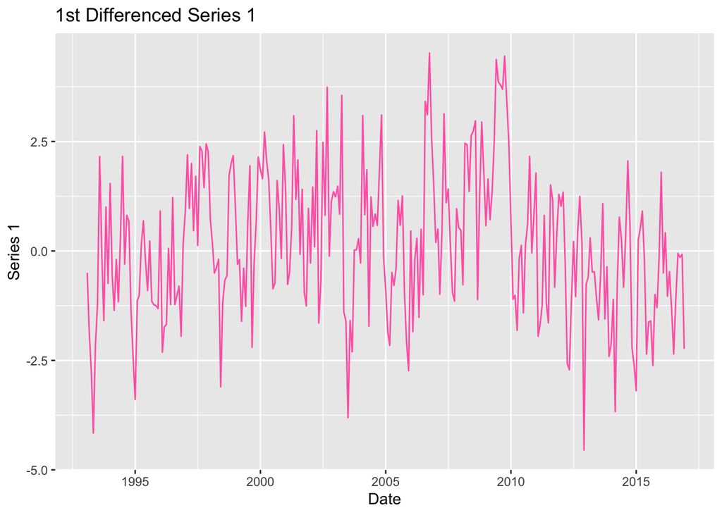

```r
#take first difference

data <- data %>%
  mutate(first_diff_series_1 = difference(series_one, difference = 1)) %>%
  mutate(sec_diff_series_1 = difference(series_one, difference = 2))

##plot first difference
ggplot(data=data) +
  geom_line(aes(x=date, y=first_diff_series_1), colour="hotpink") +
  ggtitle("1st Differenced Series 1") +
  labs(y = "Series 1", x = "Date")
```

**Plot the ACF and PACF functions and indicate if you think this should be an AR, MA, or ARMA model. From these plots choose a starting set of lags and run the appropriate regression reporting the coefficients and model fit statistics.**

The PACF decays much faster than the ACF. This indicates that we should model series one as an AR model. According to the PACF, we should use 3 lags.

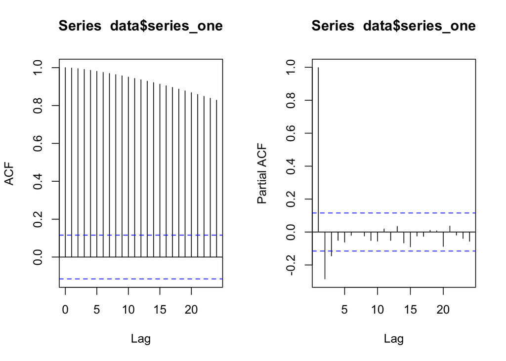

```r
#plot acf and pacf
par(mfrow = c(1,2))
acf(data$series_one, lag.max = 24)
pacf(data$series_one, lag.max = 24)
```

Using the ARIMA function with 3 “p” lags, we get 3 statistically significant coefficients for our lags as well as a BIC of 1054.58 and an AIC of 1036.27.

```r
#generate first arma model
arma1 <- Arima(data$series_one, order = c(3,0,0))
summary(arma1)
```

```
## Series: data$series_one
## ARIMA(3,0,0) with non-zero mean
##
## Coefficients:
##          ar1      ar2      ar3     mean
##       1.4323  -0.2900  -0.1449  21.1515
## s.e.  0.0584   0.1017   0.0585  22.6554
##
## sigma^2 = 2.048:  log likelihood = -513.13
## AIC=1036.27   AICc=1036.48   BIC=1054.58
##
## Training set error measures:
##                      ME     RMSE      MAE  MPE MAPE     MASE       ACF1
## Training set 0.05647396 1.421189 1.160722 -Inf  Inf 0.860983 0.01173243
```

**Try at least 2 other specifications and provide the results in a single table (I have included sample table for you to look at). Determine which model is the best according to the model selection criteria. If different criteria pick different models choose which you think is the best and defend your choice (hint: AIC is permissive, BIC is parsimonious).**

```r
##2 more model specifications
arma2 <- Arima(data$series_one, order = c(3,1,0))
summary(arma2)
```

```
## Series: data$series_one
## ARIMA(3,1,0)
##
## Coefficients:
##          ar1     ar2      ar3
##       0.4458  0.1722  -0.0670
## s.e.  0.0590  0.0638   0.0591
##
## sigma^2 = 2.041:  log likelihood = -508.25
## AIC=1024.5   AICc=1024.64   BIC=1039.13
##
## Training set error measures:
##                      ME     RMSE      MAE       MPE     MAPE      MASE
## Training set 0.05612392 1.418506 1.148895 -4.406141 17.33241 0.8522102
##                     ACF1
## Training set 0.001206193
```

```r
arma3 <- Arima(data$series_one, order = c(4,1,0))
summary(arma3)
```

```
## Series: data$series_one
## ARIMA(4,1,0)
##
## Coefficients:
##          ar1     ar2      ar3     ar4
##       0.4472  0.1687  -0.0760  0.0206
## s.e.  0.0591  0.0646   0.0645  0.0595
##
## sigma^2 = 2.047:  log likelihood = -508.19
## AIC=1026.38   AICc=1026.59   BIC=1044.67
##
## Training set error measures:
##                      ME     RMSE      MAE       MPE     MAPE      MASE
## Training set 0.05480173 1.418207 1.148765 -4.617256 17.27441 0.8521142
##                       ACF1
## Training set -0.0005433317
```

Model 2 is the best fitting model according to the model selection criteria. I have decided to use BIC to evaluate the models as I believe picking a parsimonious model means that our chosen specification only uses the explanatory variables that have a large effect on overall fit. Model 2 has the lowest BIC. However, there is also an argument to be made for choosing Model 1 which has a slightly higher BIC but all the coefficients are statistically significant where in Model 2, only the first 2 coefficents are statistically significant at the 5% level.

# Table 1: ARIMA Model Results

|  | Model 1 (ARIMA(p3,0,q0)) |  | Model 2 (ARIMA(p3,1,q0)) |  | Model 3 (ARIMA(p4,1,q0)) |  |
| --- | --- | --- | --- | --- | --- | --- |
|  | Estimate | S.E. | Estimate | S.E. | Estimate | S.E. |
| ϕ1 | 1.43 | 0.06 | 0.45 | 0.06 | 0.45 | 0.06 |
| ϕ2 | -0.29 | 0.1 | 0.17 | 0.06 | 0.17 | 0.06 |
| ϕ3 | -0.14 | 0.06 | -0.07 | 0.06 | -0.08 | 0.06 |
| ϕ4 | - | - | - | - | 0.02 | 0.06 |
| θ1 | - | - | - | - | - | - |
| θ2 | - | - | - | - | - | - |
| θ3 | - | - | - | - | - | - |
| θ4 | - | - | - | - | - | - |
| Num. Obs | 288 |  | 288 |  | 288 |  |
| AIC | 1036.265689 |  | 1024.4965991 |  | 1026.3772138 |  |
| AICc | 1036.48 |  | 1024.64 |  | 1026.59 |  |
| BIC | 1054.5804914 |  | 1039.134528 |  | 1044.6746249 |  |

# Question 2

**Using the variable ‘series_two’ from the data file, complete the following:**

**Determine if the variable is stationary. Provide any and all evidence you have to support your answer (e.g. plots, ADF test statistic, etc.).**

Series two appears to have somewhat of a trend. When we look at the intord function, we find a lot of evidence to suggest the series is difference stationary. A visual inspection, the ADF test, the decision heuristic, and the faster declining differenced ACF as compared to the levels ACF support the conclusion of difference stationarity.

However, the levels graph shows a strong trend, I detrended the data and see that the detrended graph also appears mean reverting and homoskedastic. It is clear that the data is not stationary at the levels but could be either difference or trend stationary.

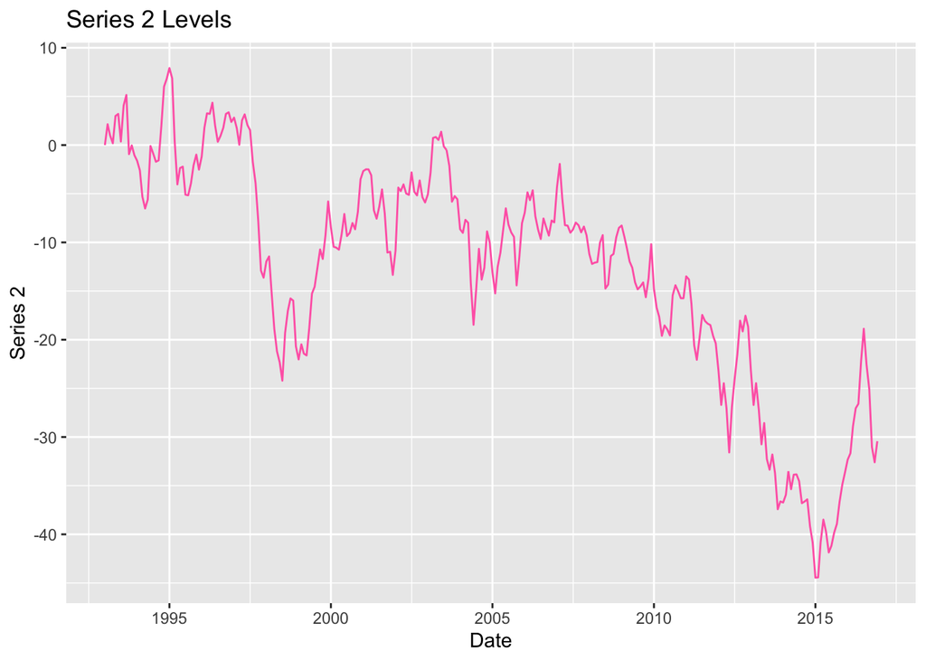

```r
#plotting series 2
ggplot(data=data) +
  geom_line(aes(x=date, y=series_two), colour="hotpink") +
  ggtitle("Series 2 Levels") +
  labs(y = "Series 2", x = "Date")
```

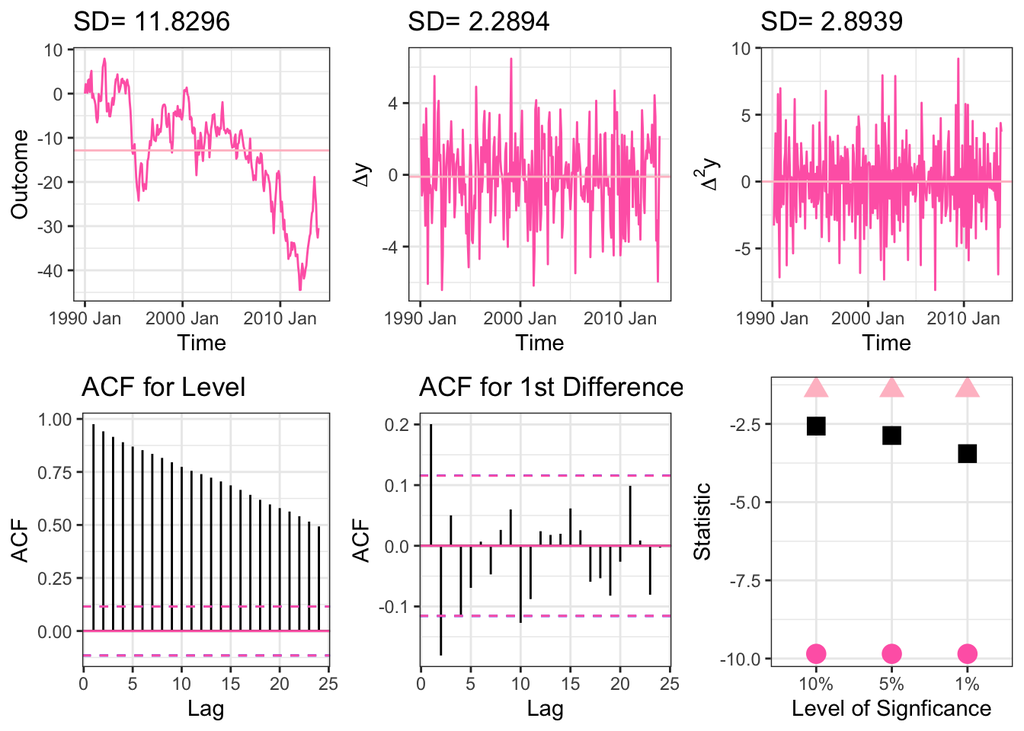

```
## $test_results
##   level crit_value ADF_round1_stat ADF_round2_stat round_1_dec round_2_dec
## 1   10%      -2.57           -1.41           -9.85         FTR         REJ
## 2    5%      -2.87           -1.41           -9.85         FTR         REJ
## 3    1%      -3.45           -1.41           -9.85         FTR         REJ
```

```r
intord(data$series_two)
```

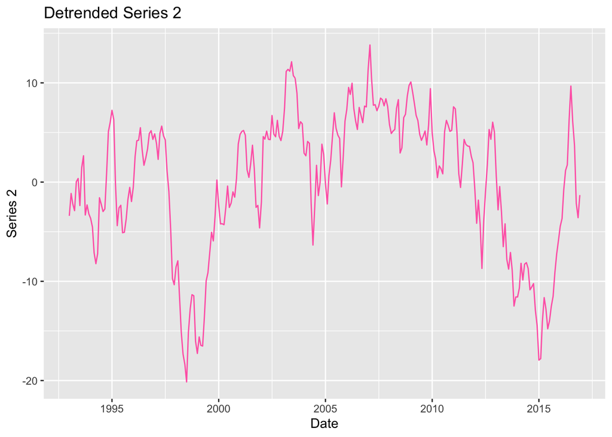

```r
#detrend the data
model <- lm(series_two ~ date, data = data)
detrend_series2 <- data %>%
  mutate(detrended_series2 = series_two - predict(model))

#plot detrended data
ggplot(data=detrend_series2) +
  geom_line(aes(x=date, y=detrended_series2), colour="hotpink") +
  ggtitle("Detrended Series 2") +
  labs(y = "Series 2", x = "Date")
```

**Plot the ACF and PACF functions and indicate if you think this should be an AR, MA, or ARMA model. From these plots choose a starting set of lags and run the appropriate regression reporting the coefficients and model fit statistics.**

The PACF declines much faster than the ACF, suggesting that this is an AR model. My first model will have 4 AR lags and 1 difference since the previous question indicated that this data is likely difference stationary.

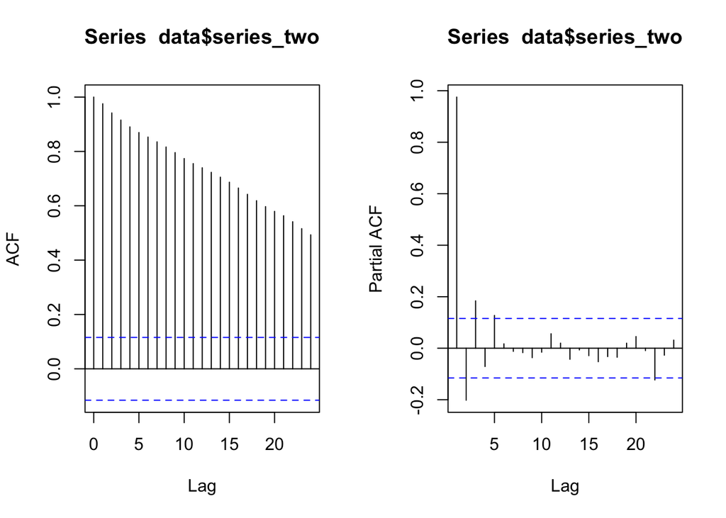

```r
#plot acf and pacf
par(mfrow = c(1,2))
acf(data$series_two, lag.max = 24)
pacf(data$series_two, lag.max = 24)
```

```r
#first arma model
arma1 <- Arima(data$series_two, order = c(4,1,0))
summary(arma1)
```

```
## Series: data$series_two
## ARIMA(4,1,0)
##
## Coefficients:
##          ar1      ar2     ar3      ar4
##       0.3224  -0.3308  0.2233  -0.2346
## s.e.  0.0574   0.0591  0.0594   0.0580
##
## sigma^2 = 4.442:  log likelihood = -619.43
## AIC=1248.85   AICc=1249.07   BIC=1267.15
##
## Training set error measures:
##                      ME     RMSE      MAE       MPE     MAPE     MASE
## Training set -0.1037466 2.089283 1.650178 -44.05587 82.99419 0.909796
##                    ACF1
## Training set 0.01728116
```

**Plot the ACF and PACF functions for the first 50 and 100 observations respectively. Discuss the differences between these plots and the ones you made for part (ii).**

The ACF for the first 50 observations declines much faster than the ACF for the first 100 and the ACF for the entire data series. Using the PACF for the first 50 observations, I might only choose 2 lags. Further, the PACF does not decline as fast compared to the ACF as it does looking at the whole series which could provide evidence that I should include an MA term in this specification as well.

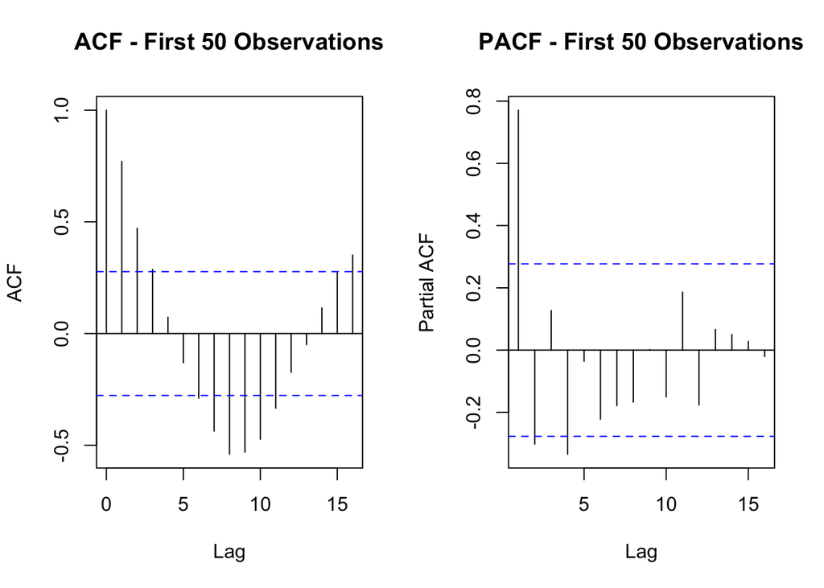

```r
#taking the first 50 and 100 observatiosn and plotting their respective acfs and pacfs
first_50_obs <- data$series_two[1:50]
first_100_obs <- data$series_two[1:100]

ts_first_50 <- ts(first_50_obs)
ts_first_100 <- ts(first_100_obs)

# Plot ACF and PACF for the first 50 observations
par(mfrow=c(1,2))
acf(ts_first_50, main="ACF - First 50 Observations")
pacf(ts_first_50, main="PACF - First 50 Observations")
```

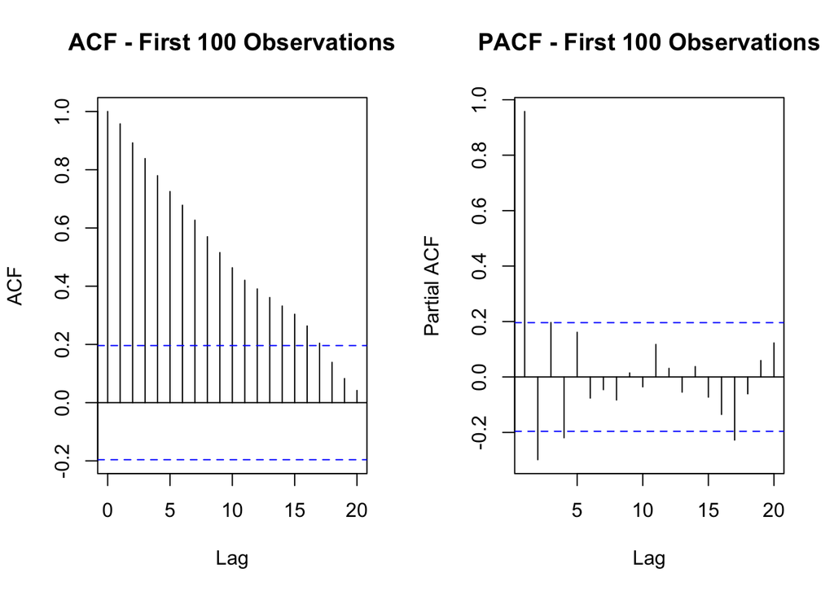

```r
# Plot ACF and PACF for the first 100 observations
par(mfrow=c(1,2))
acf(ts_first_100, main="ACF - First 100 Observations")
pacf(ts_first_100, main="PACF - First 100 Observations")
```

**Try at least 2 other specifications and provide the results in a single table (I have included sample table for you to look at). Determine which model is the best according to the model selection criteria. If different criteria pick different models choose which you think is the best and defend your choice (hint: AIC is permissive, BIC is parsimonious).**

Using BIC as my selection criteria, model 3 is the best fitting model, specified as (4,1,1).

```r
##2 more model specifications
arma2 <- Arima(data$series_two, order = c(5,1,0))
summary(arma2)
```

```
## Series: data$series_two
## ARIMA(5,1,0)
##
## Coefficients:
##          ar1      ar2     ar3      ar4     ar5
##       0.3416  -0.3491  0.2516  -0.2608  0.0842
## s.e.  0.0588   0.0603  0.0625   0.0607  0.0597
##
## sigma^2 = 4.427:  log likelihood = -618.44
## AIC=1248.88   AICc=1249.18   BIC=1270.83
##
## Training set error measures:
##                       ME     RMSE      MAE       MPE     MAPE      MASE
## Training set -0.09755513 2.081976 1.634208 -44.44456 83.40315 0.9009914
##                     ACF1
## Training set 0.006873233
```

```r
arma3 <- Arima(data$series_two, order = c(4,1,1))
summary(arma3)
```

```
## Series: data$series_two
## ARIMA(4,1,1)
##
## Coefficients:
##           ar1      ar2     ar3      ar4     ma1
##       -0.4511  -0.0952  0.0036  -0.0494  0.8268
## s.e.   0.1007   0.0710  0.0712   0.0723  0.0838
##
## sigma^2 = 4.351:  log likelihood = -616.06
## AIC=1244.12   AICc=1244.42   BIC=1266.08
##
## Training set error measures:
##                       ME     RMSE     MAE       MPE    MAPE      MASE
## Training set -0.09336305 2.064005 1.63121 -41.99839 81.1233 0.8993384
##                      ACF1
## Training set -0.005870908
```

# Table 2: ARIMA Model Results

|  | Model 1 (ARIMA(p4,1,q0)) |  | Model 2 (ARIMA(5,1,q0)) |  | Model 3 (ARIMA(p4,1,q1)) |  |
| --- | --- | --- | --- | --- | --- | --- |
|  | Estimate | S.E. | Estimate | S.E. | Estimate | S.E. |
| ϕ1 | 0.32 | 0.06 | 0.34 | 0.06 | -0.45 | 0.1 |
| ϕ2 | -0.33 | 0.06 | -0.35 | 0.06 | -0.1 | 0.07 |
| ϕ3 | 0.22 | 0.06 | 0.25 | 0.06 | 0 | 0.07 |
| ϕ4 | -0.23 | 0.06 | -0.26 | 0.06 | -0.05 | 0.07 |
| θ1 | - | - | - | - | 0.83 | 0.08 |
| θ2 | - | - | - | - | - | - |
| θ3 | - | - | - | - | - | - |
| θ4 | - | - | - | - | - | - |
| Num. Obs | 288 |  | 288 |  | 288 |  |
| AIC | 1248.8546596 |  | 1248.8776065 |  | 1244.1226449 |  |
| AICc | 1249.07 |  | 1249.18 |  | 1244.42 |  |
| BIC | 1267.1520707 |  | 1270.8344998 |  | 1266.0795382 |  |

# Question 3

**Using the variable ‘series_three’ from the data file, complete the following:**

**Determine if the variable is stationary. Provide any and all evidence you have to support your answer (e.g. plots, ADF test statistic, etc.).**

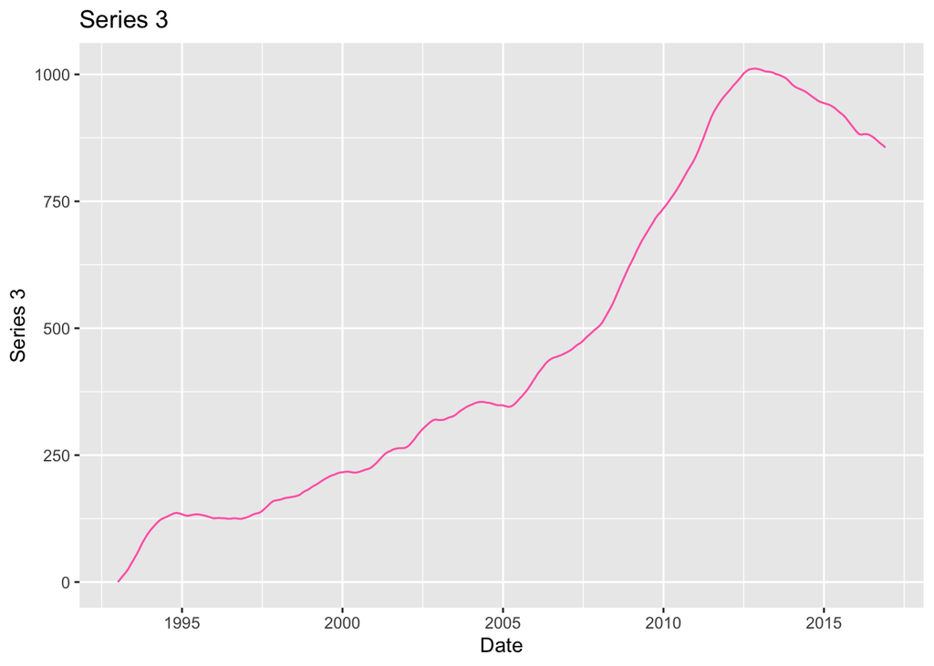

```r
#plotting series 3
ggplot(data=data) +
  geom_line(aes(x=date, y=series_three), colour="hotpink") +
  ggtitle("Series 3") +
  labs(y = "Series 3", x = "Date")
```

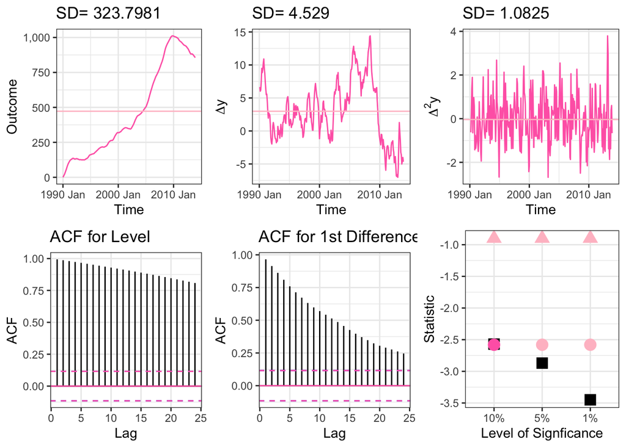

```
## $test_results
##   level crit_value ADF_round1_stat ADF_round2_stat round_1_dec round_2_dec
## 1   10%      -2.57            -0.9           -2.58         FTR         REJ
## 2    5%      -2.87            -0.9           -2.58         FTR         FTR
## 3    1%      -3.45            -0.9           -2.58         FTR         FTR
```

```r
#additional evidence for difference stationarity
intord(data$series_three)
```

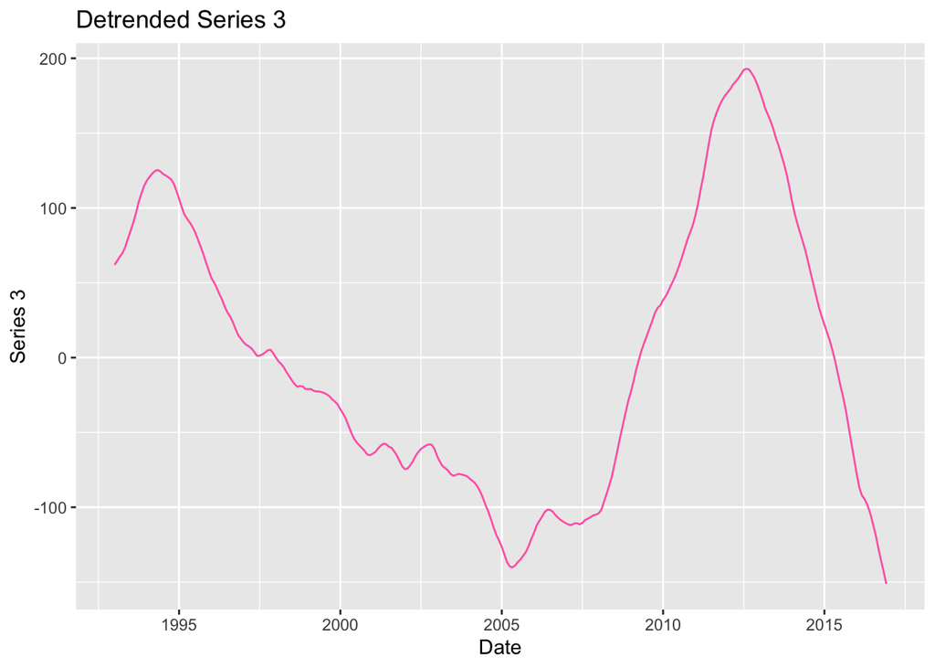

```r
#detrend the data
model <- lm(series_three ~ date, data = data)
detrend_series3 <- data %>%
  mutate(detrended_series3 = series_three - predict(model))

#plot detrended data
ggplot(data=detrend_series3) +
  geom_line(aes(x=date, y=detrended_series3), colour="hotpink") +
  ggtitle("Detrended Series 3") +
  labs(y = "Series 3", x = "Date")
```

**Plot the ACF and PACF functions and indicate if you think this should be an AR, MA, or ARMA model. From these plots choose a starting set of lags and run the appropriate regression reporting the coefficients and model fit statistics.**

The PACF declines much faster than the ACF, suggesting that this is an AR model. My first model will have 1 AR lag.

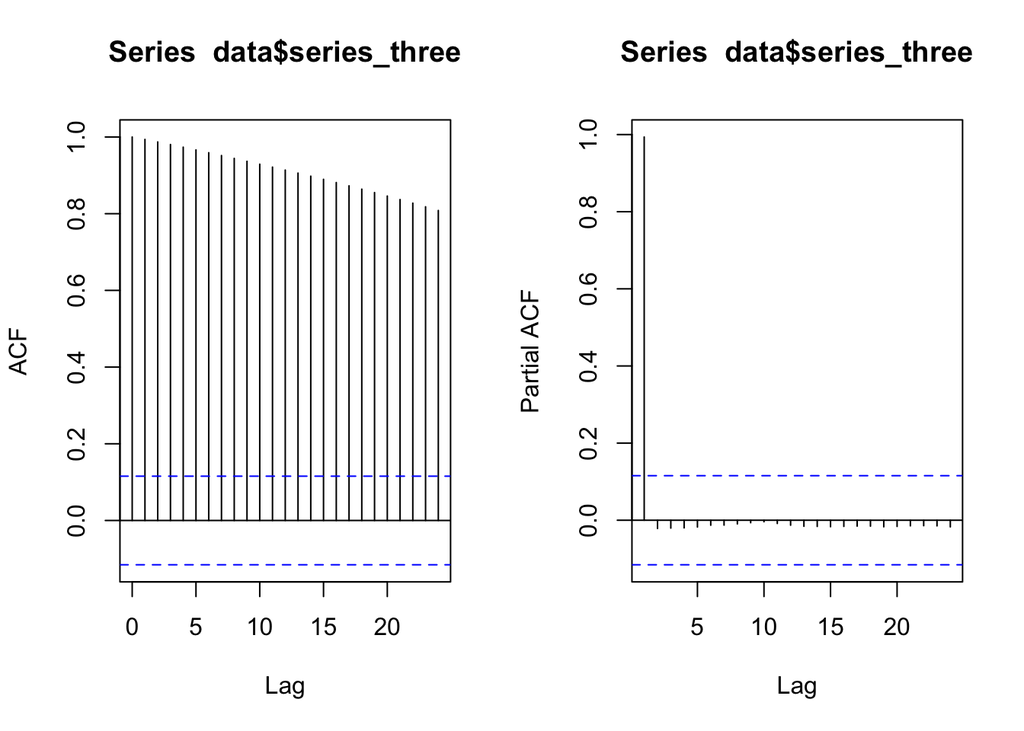

```r
#plot the acf and pacf
par(mfrow = c(1,2))
acf(data$series_three, lag.max = 24)
pacf(data$series_three, lag.max = 24)
```

```r
#first arma model
arma1 <- Arima(data$series_three, order = c(1,0,0))
summary(arma1)
```

```
## Series: data$series_three
## ARIMA(1,0,0) with non-zero mean
##
## Coefficients:
##          ar1      mean
##       0.9999  457.9583
## s.e.  0.0001  421.9695
##
## sigma^2 = 29.54:  log likelihood = -899.55
## AIC=1805.1   AICc=1805.18   BIC=1816.09
##
## Training set error measures:
##                    ME     RMSE      MAE  MPE MAPE      MASE      ACF1
## Training set 2.952348 5.416071 4.282276 -Inf  Inf 0.9993099 0.9473091
```

**Plot the ACF and PACF functions for the first 50 and 100 observations respectively. Discuss the differences between these plots and the ones you made for part (ii).**

The ACF for the first 50 observations declines much faster than the ACF for the first 100 and the ACF for the entire data series. Looking at these segmented sections of the data would not change my determination of how many AR terms I should include in the model since I still think 1 AR lag is adequate based on the PACF.

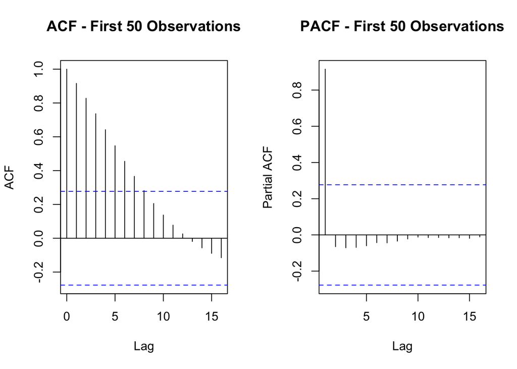

```r
#plotting the acf and pacf for the first 50 and first 100 observations respectively
first_50_obs <- data$series_three[1:50]
first_100_obs <- data$series_three[1:100]

ts_first_50 <- ts(first_50_obs)
ts_first_100 <- ts(first_100_obs)

# Plot ACF and PACF for the first 50 observations
par(mfrow=c(1,2))
acf(ts_first_50, main="ACF - First 50 Observations")
pacf(ts_first_50, main="PACF - First 50 Observations")
```

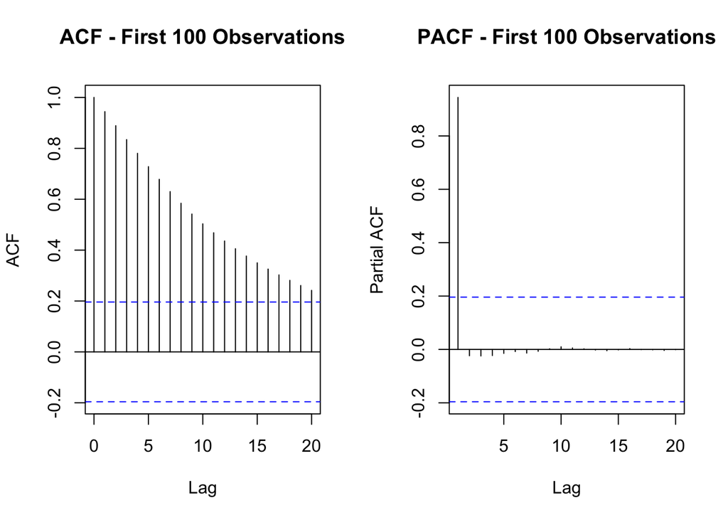

```r
# Plot ACF and PACF for the first 100 observations
par(mfrow=c(1,2))
acf(ts_first_100, main="ACF - First 100 Observations")
pacf(ts_first_100, main="PACF - First 100 Observations")
```

**Try at least 2 other specifications and provide the results in a single table (I have included sample table for you to look at). Determine which model is the best according to the model selection criteria. If different criteria pick different models choose which you think is the best and defend your choice (hint: AIC is permissive, BIC is parsimonious).**

Using BIC as my model selection criteria, I choose model 3 since the BIC value is the lowest at 842.15.

```r
##2 more model specifications
arma2 <- Arima(data$series_three, order = c(1,1,0))
summary(arma2)
```

```
## Series: data$series_three
## ARIMA(1,1,0)
##
## Coefficients:
##          ar1
##       0.9804
## s.e.  0.0108
##
## sigma^2 = 1.162:  log likelihood = -429.91
## AIC=863.81   AICc=863.85   BIC=871.13
##
## Training set error measures:
##                      ME     RMSE       MAE       MPE      MAPE      MASE
## Training set 0.02373929 1.074213 0.8604013 0.1033154 0.4228959 0.2007828
##                   ACF1
## Training set 0.3132691
```

```r
arma3 <- Arima(data$series_three, order = c(1,1,1))
summary(arma3)
```

```
## Series: data$series_three
## ARIMA(1,1,1)
##
## Coefficients:
##          ar1     ma1
##       0.9682  0.3599
## s.e.  0.0144  0.0557
##
## sigma^2 = 1.033:  log likelihood = -412.59
## AIC=831.17   AICc=831.26   BIC=842.15
##
## Training set error measures:
##                     ME     RMSE       MAE       MPE      MAPE      MASE
## Training set 0.0442741 1.010857 0.8035478 0.1044995 0.4017505 0.1875155
##                      ACF1
## Training set 0.0005695659
```

# Table 3: ARIMA Model Results Series 3

|  | Model 1 (ARIMA(p1,0,q0)) |  | Model 2 (ARIMA(p1,1,q0)) |  | Model 3 (ARIMA(p1,1,q1)) |  |
| --- | --- | --- | --- | --- | --- | --- |
|  | Estimate | S.E. | Estimate | S.E. | Estimate | S.E. |
| ϕ1 | 1 | 0 | 0.98 | 0.01 | 0.97 | 0.01 |
| ϕ2 | NA | NA | NA | NA | NA | NA |
| ϕ3 | NA | NA | NA | NA | NA | NA |
| ϕ4 | - | - | - | - | - | - |
| θ1 | - | - | - | - | 0.36 | 0.06 |
| θ2 | - | - | - | - | - | - |
| θ3 | - | - | - | - | - | - |
| θ4 | - | - | - | - | - | - |
| Num. Obs | 288 |  | 288 |  | 288 |  |
| AIC | 1805.0995073 |  | 863.8105718 |  | 831.1748666 |  |
| AICc | 1805.18 |  | 863.85 |  | 831.26 |  |
| BIC | 1816.0883887 |  | 871.1295362 |  | 842.1533133 |  |